[figure not shown]

# Разработка метода продолжения решений посредством автоматического дифференцирования

Малышев Сергей

Февраль 23, 2021

## Преамбула

Метод продолжения решений - это численный метод позволяющий рассчитывать ратификационные диаграммы для нелинейных систем. В настоящей работе предлагается новый подход для реализации данного метода. Мы предлагаем использовать метод автоматического дифференцирования для нахождения матрицы Якоби которая необходима для расчетов.

## Содержание

Данный доклад состоит из следующий логических разделов:

1. Введение в введение в автоматическое дифференцирование.
2. Задача продолжения по параметру, классические подходы к вычислению матрицы Якоби.
3. Вычисление матрицы Якоби методом автоматического дифференцирования.
4. Примеры с кодом.

## Автоматическое дифференцирование

Вспомним некоторые фундаментальные понятия.

Дифференцирование сложной функции.

- Рассмотрим следующею сложную функцию.
  $$y = f(g(h(x))) = f(g(h(w_0))) = f(g(w_1)) = f(w_2) = w_3$$
  - сложная функция
- Производную такой функции можно вычислить по формуле:
  $$\frac{dy}{dx} = \frac{dy}{dw_2} \frac{dw_2}{dw_1} \frac{dw_1}{dx} = \frac{df(w_2)}{dw_2} \frac{dg(w_1)}{dw_1} \frac{dh(w_0)}{dx}$$

## Автоматическое дифференцирование

Существует два принципиально разных подхода к реализации автоматического дифференцирования.

- Прямой - сначала мы вычесляем $\frac{dw_1}{dx}$ затем $\frac{dw_2}{dw_1}$ и так далее.
- Обратный - сначала мы вычесляем $\frac{dy}{dw_2}$ затем $\frac{dw_2}{dw_1}$ и так далее.

Поскольку в настоящей работе используется прямой метод, на нем остановимся подробнее. Обратный метод предлагается освоить слушателю самостоятельно.

## Автоматическое дифференцирование

- Прямой - сначала мы вычесляем $\frac{dw_1}{dx}$ затем $\frac{dw_2}{dw_1}$ и так далее.
- Обратный - сначала мы вычесляем $\frac{dy}{dw_2}$ затем $\frac{dw_2}{dw_1}$ и так далее.

Поскольку в настоящей работе используется прямой метод, на нем остановимся подробнее. Обратный метод предлагается освоить слушателю самостоятельно.

## Дерево выражений

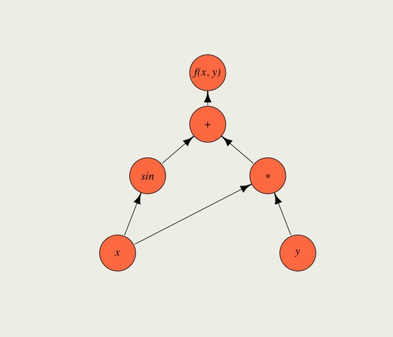

## Вычисление производной

[output not shown]

## Дуальное число

Прямой метод можно реализовать при помощи дуальных чисел.

Дуальное число - это гиперкомплексное число вида
$$a + \varepsilon b,$$

где $a, b \in \mathbb{R}$, a $\varepsilon^2 = 0$.

Над дуальными числами определенны операции сложения и произведения:
$$(a_1 + \varepsilon b_1) + (a_2 + \varepsilon b_2) = (a_1 + a_2) + \varepsilon(b_1 + b_2)$$
$$(a_1 + \varepsilon b_1) (a_2 + \varepsilon b_2) = (a_1 a_2) + \varepsilon(a_1 b_2 + b_1 a_2)$$

## Погружаемся глубже в поле дуальных чисел

Производная частного:
$$(\frac{u}{v})' = \frac{u' v - v' u} {v^2}$$

## Реализация прямого метода с помощью дуальных чисел

Применим дуальные числа для реализации автоматического дифференцирования. Запишем дуальное число в следующем виде.
$$u = u + \varepsilon u',$$
где $u'$ - производная $u$.

Перегрузив операции сложения, произведения, и т.д, а так же приняв $u' = 1$ для интересующей независимой переменной вычислим значение функции $f: D -> D$ используя дуальные числа.

$$f(x_0) = y_0 + \varepsilon y_0',$$

где $y_0' = \frac{df}{dx}|_{x = x_0}$

## Метод продолжения переодических решений

Постановка проблемы для задачи продолжения переодических решений. Дана следующая динамическая система.

$$\dot{q} = \theta(q, t, \lambda)$$

где $q \in \mathbb{R}^m, \theta(q, t) = \theta(q, t + T)$ - $T$ -периодическая функция по явно входящему времени, $\lambda$ - некоторый характеристический параметр.

Если исследуются колебания с периодом $T$, то краевые условия (условия периодичности) имеют вид:

$$q(0) = q(t)$$

## Метод продолжения переодических решений

Рассмотрим задачу Коши для системы $\dot{q} = \theta(q, t, \lambda)$ с начальными условиями $q(0) = q_0$ Решение задачи в точке $T$ обозначим как $q(T) = q_lT$ и подставляя обозначения в краевые условия $q(0) = q(t)$ получим следующею систему нелинейных уравнений:

$$F(q_0, \lambda) = q_{T} - q_0 = 0$$

## Newton

## Метод продолжения решений Moore-Penrose

```cpp
#include <iostream>
#include <fstream>
using namespace std;

#include <nld/autocont.hpp>
using namespace nld;

int main() {
    continuation_parameters params(newton_parameters(10, 0.000001),
      1.45, 0.0002, 0.008, direction::forward);

    vector_xdd u0 = vector_xdd::Zero(2);
    dual_d a0 = 0.0;

    for (auto [v, p] : arc_length(f, params, u0, alpha0, to_2d<0>)) {
        cout << p << ';'<< v << endl;
    }
}
```

## Биффуркационная диаграмма

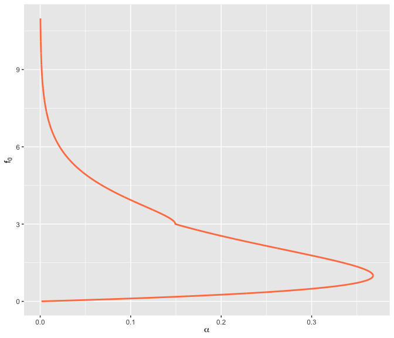